# Applying MIRA to a Biological Question

John Lawson

2017-04-08

# Contents

In this vignette, we are adding annotation and using multiple samples and region sets. Only the second half of this vignette is evaluated because of the large files involved.

## 0.1 Biological Question

Ewing sarcoma is a pediatric cancer defined by the fusion oncoprotein EWS-FLI1, a transcription factor. We have DNA methylation data for Ewing sarcoma samples and we want to use this data to see if Ewing samples can be distinguished from muscle-related samples. We will use MIRA to infer regulatory activity and compare MIRA scores for Ewing versus muscle samples in two region sets: First, Ewing-specific DNase hypersensitivity sites (DHSs), and second, muscle-specific DHSs.

### 0.1.1 Input:

This vignette requires large input files, which can be dowloaded here: MIRA_vignette_files.tgz. This archive contains: * Single-nucleotide resolution DNA methylation data (RRBS data) for 12 Ewing sarcoma samples and 12 myotube (muscle) samples recently analyzed in the paper [DNA methylation heterogeneity defines a disease spectrum in Ewing sarcoma](http://www.medical-epigenomics.org/papers/sheffield2017/). * Two sets of regions – one with Ewing-specific DHSs and a one with muscle-specific DHSs, obtained from the [Regulatory Elements Database](http://db.databio.org/). All data is on the hg38 reference genome.

## 0.2 Package workflow

0. Start with appropriately formatted single-nucleotide resolution methylation data, region sets – each with genomic regions corresponding to some biological annotation, and an annotation file that has sample name (sampleName column) and sample type (sampleType column).
1. Do a quick run-through of the MIRA workflow with each region set with a few samples from each condition/sample type to make sure the region sizes are reasonable (discussed later).  
   1.1. Aggregate methylation data in bins across all regions in each region set to get a MIRA signature for each region set, sample combination.  
   1.2. Calculate MIRA score for each region set, sample combination based on the shape of the MIRA signature.
2. Based on preliminary results, pick a region size for each region set depending on what the MIRA signatures look like.
3. Run the full MIRA analysis with chosen region sizes.  
   3.1. Split the regions into bins and aggregate methylation data in those bins to get a MIRA signature for each region set, sample combination.  
   3.2. Calculate MIRA score for each region set, sample combination based on the shape of the MIRA signature.

### 0.2.1 Initial Run-through

First, let’s load the libraries and read in the data files.

```r
library(MIRA)
library(data.table) #fread, setkey,
library(GenomicRanges) #GRanges, resize
data(exampleAnnoDF2)#object name: "exampleAnnoDF2", data.table
```

```r
# 12 Ewing samples: T1-T12
caseFiles = paste0("EWS_T", 1:12, ".bed")
# 12 muscle related samples, 3 of each type
controlFiles = c("Hsmm_", "Hsmmt_", "Hsmmfshd_","Hsmmtubefshd_")
controlFiles=paste0(controlFiles, rep(1:3, each = 4), ".bed")
RRBSFiles = c(caseFiles, controlFiles)
regionSetFiles = c("sknmc_specific.bed", "muscle-specific.bed")
BSDTList = lapply(X = RRBSFiles, FUN = BSreadBiSeq)
regionSets = lapply(X = regionSetFiles, FUN = fread)
```

Now we just need to get the data in the right format and pick initial region sizes. To get the methylation profile around our sites of interest, we are resizing the regions to 5000 bp. This is a wide initial guess compared to the average region sizes for the region sets (around 151 bp for both region sets), but we will adjust this later on.

```r
regionSets = lapply(X = regionSets,
                    FUN = function(x) setNames(x, c("chr", "start", "end")))
#converting list items from data.table to GRanges objects
#strand is not relevant for our region sets
regionSets = lapply(X = regionSets, FUN =
                        function(x) GRanges(seqnames = x$chr,
                                              ranges = IRanges(x$start, x$end)))
regionSets[[1]] = resize(regionSets[[1]], 5000, fix = "center")
regionSets[[2]] = resize(regionSets[[2]], 5000, fix = "center")
names(regionSets) = c("Ewing_Specific", "Muscle_Specific")
```

Now we are ready to run MIRA on a subset of the samples. First, we aggregate the methylation data into bins with `returnMIRABins`. MIRA divides each region into bins and finds methylation that is contained in each bin in each region. Then matching bins are aggregated over all regions (all bin1’s together, all bin2’s together, etc.). An odd bin number is recommended for the sake of symmetry and MIRA scoring.

```r
subBSDTList=BSDTList[c(1, 5, 9, 13, 17, 21)] # three of each type
bigBin = lapply(X = subBSDTList, FUN = returnMIRABins, GRList = regionSets,
                binNum = 21, minReads = 0, sampleNameInBSDT = TRUE)
bigBinDT1 = rbindlist(bigBin)
```

Next we add on annotation data: the experimental condition or sample type for each sample.

```r
# loading "bigBinDT1" object using data()
# which has binned methylation data for this step of the vignette
data(ewingMyobigBinDT1)
# data.table functions are used to add info from annotation object to bigBinDT1
setkey(exampleAnnoDF2, sampleName)
setkey(bigBinDT1, sampleName)
bigBinDT1 = merge(bigBinDT1, exampleAnnoDF2, all.x = TRUE) #adding annotation
```

Let’s look at the MIRA signatures to see if we should change our region sizes.

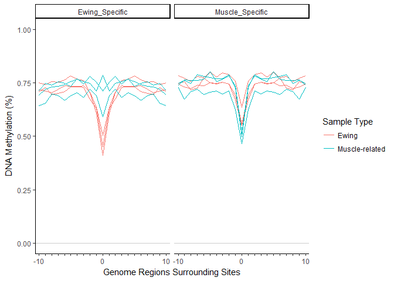

```r
plotMIRARegions(binnedRegDT = bigBinDT1)
```

### 0.2.2 Choosing Appropriate Region Sizes

While the methylation profiles looked pretty good, the dips are kind of narrow for the muscle-related samples when looking at the muscle-specific region set. The scoring function in MIRA could run into problems if the dips are too narrow since it expects the dips to be at least 5 bins wide from outside edge to outside edge (that number includes the outside edges). Let’s use smaller region sizes for both region sets: 4000 bp for the Ewing DHS regions and 1750 bp for the muscle DHS regions although the exact choice is somewhat arbitrary. The size of the regions should not be decreased too much however. If the regions are too small, there might be more noise since there would be less methylation data for each bin. Also, the regions must be wide enough to capture the outer edges of the dip since the outer edges are used for the MIRA score.

To implement our new region sizes:

```r
regionSets[[1]] = resize(regionSets[[1]], 4000, fix = "center") # Ewing
regionSets[[2]] = resize(regionSets[[2]], 1750, fix = "center") # muscle
```

### 0.2.3 Full MIRA Analysis

Now we can run MIRA with all our samples. Let’s aggregate methylation data again with `returnMIRABins`.

```r
bigBin = lapply(X = BSDTList, FUN = returnMIRABins, GRList = regionSets,
                binNum = 21, minReads = 0, sampleNameInBSDT = TRUE)
bigBinDT2 = rbindlist(bigBin)
```

We add annotation data using the same process as before:

```r
# loading "bigBinDT2" object using data()
# which has binned methylation data for this step of the vignette
data(ewingMyobigBinDT2)
# data.table functions are used to add info from annotation object to bigBinDT2
setkey(exampleAnnoDF2, sampleName)
setkey(bigBinDT2, sampleName)
bigBinDT2 = merge(bigBinDT2, exampleAnnoDF2, all.x = TRUE) #adding annotation
```

Let’s look at the MIRA signatures.

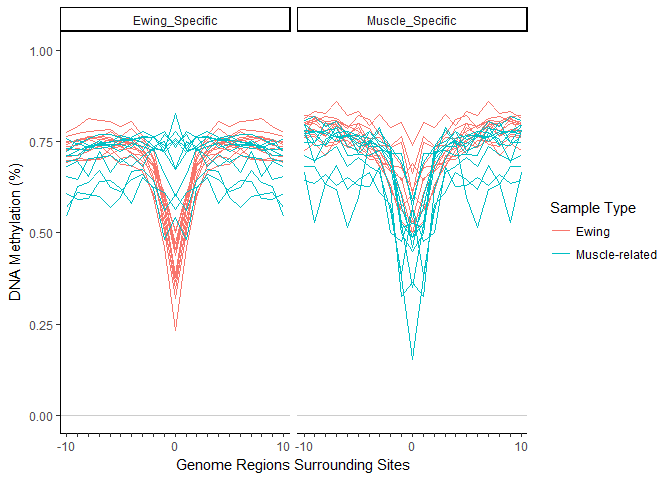

```r
plotMIRARegions(binnedRegDT = bigBinDT2)
```

Next we normalize the binned methylation data (the MIRA signature). Normalizing by subtracting the minimum methylation bin value from each sample/region set combination generally brings the center MIRA signatures to a similar methylation value, making the MIRA score more about the shape of the signature and less about the average methylation. We do this with `data.table` syntax.

```r
bigBinDT2[, methyl := methyl - min(methyl) + .05, by = .(featureID, sampleName)]
```

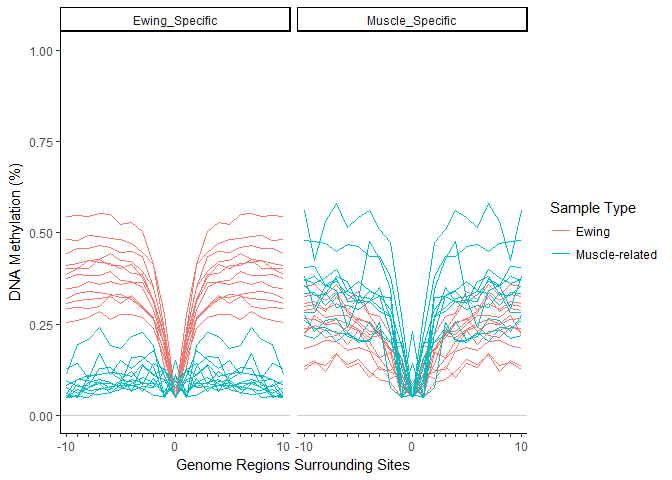

```r
plotMIRARegions(binnedRegDT = bigBinDT2)
```

Now we can calculate MIRA scores for all samples with the `scoreDip` function, again using `data.table` syntax.

```r
sampleScores = bigBinDT2[, .(score = scoreDip(methyl,
                                             binCount = 21,
                                             shoulderShift = "auto")),
                        by = .(featureID, sampleName)]
head(sampleScores)
```

```
##         featureID sampleName    score
## 1: Ewing_Specific     EWS_T1 2.180698
## 2: Ewing_Specific    EWS_T10 2.114649
## 3: Ewing_Specific    EWS_T11 2.064900
## 4: Ewing_Specific    EWS_T12 2.290313
## 5: Ewing_Specific     EWS_T2 1.987881
## 6: Ewing_Specific     EWS_T3 2.230074
```

Finally, let’s add the annotation data back on and take a look at the scores!

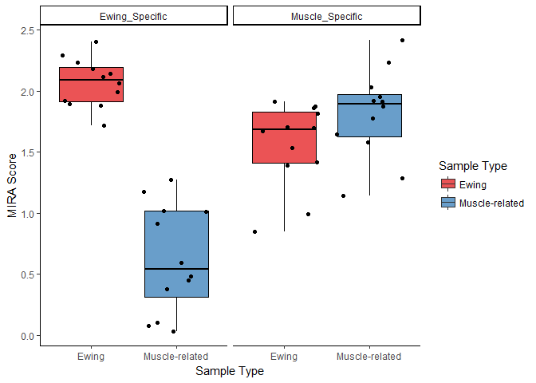

```r
setkey(exampleAnnoDF2, sampleName)
setkey(sampleScores, sampleName)
#adding annotation
sampleScores = merge(sampleScores, exampleAnnoDF2, all.x = TRUE)
plotMIRAScores(sampleScores)
```

## 0.4 Other Tips for Using MIRA

When it comes to MIRA, lapply is your friend (although this is generally true anyway). This allows for distributed computing with mclapply if desired.